# What My Mutual Liked Reels Say

[figure not shown]

## Overview

Here is a data breakdown of 100 Instagram Reels of what my mutuals have liked. This includes data points from posting time, engagement rates, and what the algorithm tries to display. All of the data was sourced manually by scrolling through Instagram and submitting observations through my own form that was converted into a CSV to be used and explored in R.

## Comedy and Memes Domination

While scrolling through Instagram there are quite a few different styles of content that each reel could be categorised into. I decided on the following arbitrary content categories: `Comedy & Memes`, `Travel`, `Music`, `Fitness & Health`, `Fashion & Beauty`, `Food & Cooking` and `Art`. Depending on the reel it generally overlapped with those categories.

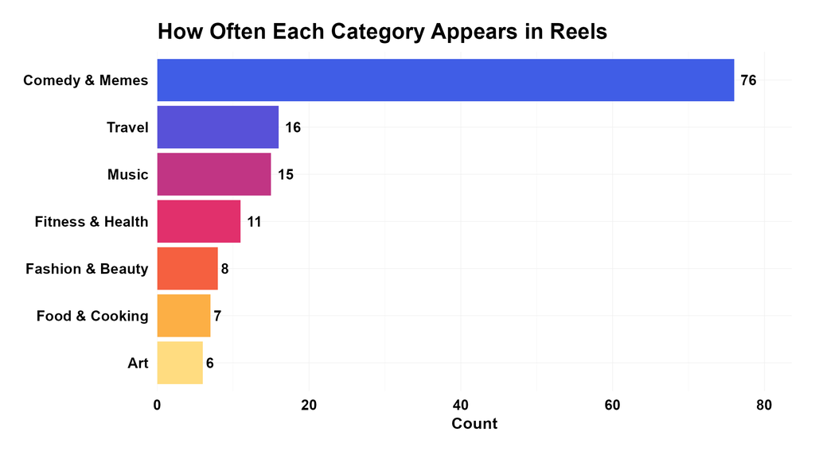

Horizontal bar chart showing the counts of each content category. With each bar coloured individually mimicing Instagrams colour palette.

As seen, when it comes to reels my mutuals had liked, the most dominant category was `Comedy & Memes` at a count of `76` which is more than *4x* the next highest category. Other somewhat popular categories included `Travel` and `Music`.

## More Views Means More Likes

Across all reels, the relationship between views and likes are quite linear on a logarithmic scale. Potentially suggesting that the content my mutuals like is broadly popular and not niche regardless of whether the poster is verified or not.

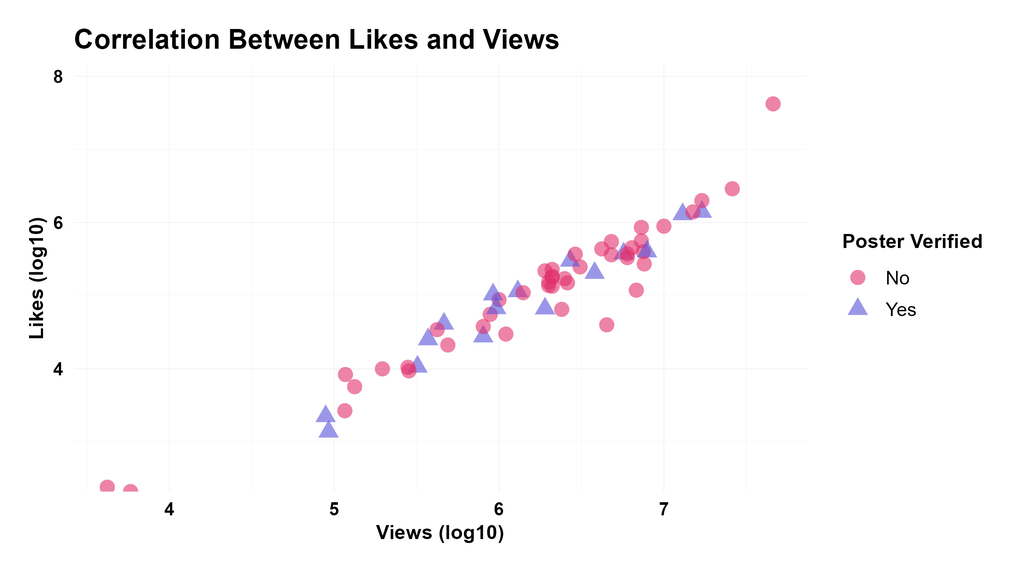

A point/scatter plot comparing log10 views on the x-axis against log10 likes on the y-axis. Points are shaped and coloured based on whether the poster was verified with red circles for non verified and blue triangles for verified. Both groups follow the same positive linear trend.

Interesting to see the one notable outlier that is above the general trend was a reel with `~42M` likes and `~46M` views. That means around `91.3%` of the viewers who saw the reel liked it which is really crazy to see.

## Lifecycle of Reels

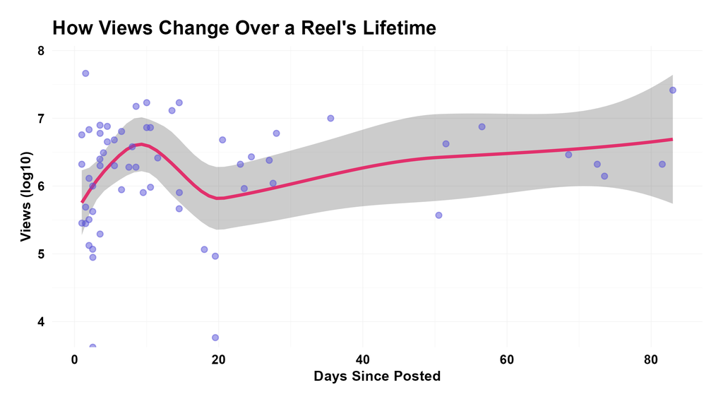

Smoothed line chart showing log10 views on the y-axis against days since posted on the x-axis. Each reel is shown as blue circle points. A widegrey confidence bance starts narrow at the start then widens greatly as weeks pass.

There is quite a wide variability suggesting that some reels will keep garnering views while others normally flatten out after a month or so after its posted.

## Original Audio is Just Better

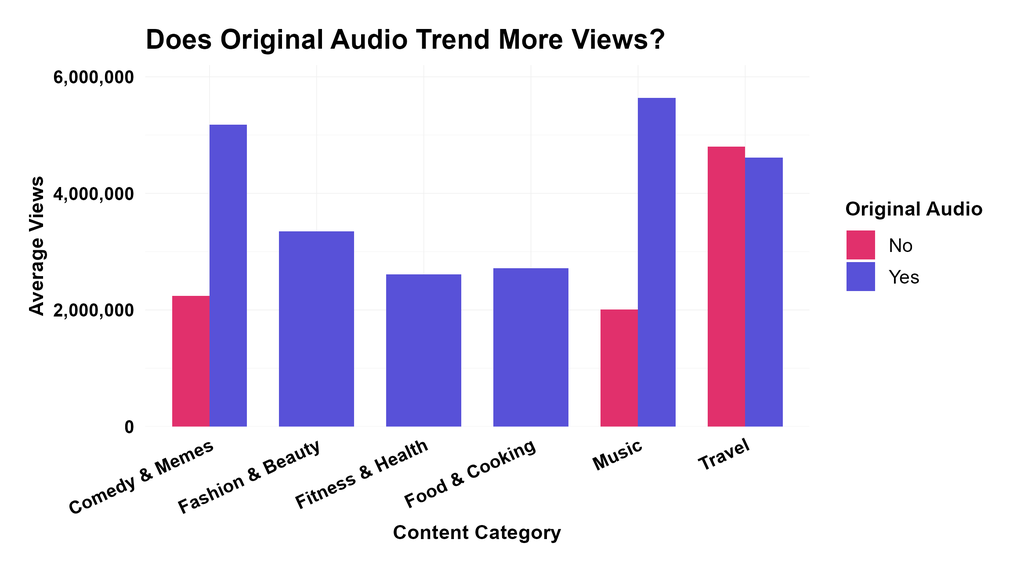

Grouped bar chart that has average views on the y-axis and content category on the x-axis with each bar split on whether the reel used original audio. Blue bars represent original was used and red bars otherwise.

It is also interesting to note that this trend isn’t the same for the content category `Travel` where using original audio or not had a negligible difference in average views.

## More Reels on a Friday

Reels posted on a `Friday` appeared much more in my mutuals liked reels followed by `Thursday` and `Saturday`. There does seem to be a pattern that posting at the end of the week as opposed to the start of the week appeared more in my feed.

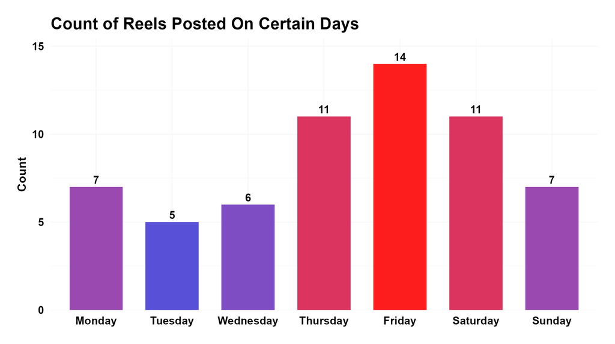

Bar chart that shows the count of reels that were posted on days of the week.

*Note that the sum of all the counts doesn’t add up to the total 100 observations as reel post date was only collected at the start of project 4.*